# Domain Tree Analysis

Gerry Tonkin-Hill

11/11/2015

## Load libraries

```r
library(ggplot2)
library(reshape2)
library(edgeR)
library(plyr)
library(scales)

library(Rsubread)
library(structSSI)
library(data.table)
library(igraph)

library(cluster)
library(fastcluster)
library(RFLPtools)

library(pheatmap)
library(EDASeq)
library(dynamicTreeCut)
library(moduleColor)
library(knitr)

library(DESeq2)

wd = "./"
colors <- c("#0571b0", "#ca0020")
```

## Get read counts for each domain

Used featureCounts allowing for overlap. That is, if a read overlaps more than one segment it is counted as a hit for both segments.

```r
setwd(wd)
# files <-
# Sys.glob('/home/users/allstaff/tonkin-hill.g/gene_level_var_analysis/alignments_seperate_assemblies_best1/*.sam')
# dom_counts <- featureCounts(files, annot.ext =
# './data/NTS_DBL_CIDR_seperate_assembly_domains.SAF' , isPairedEnd=TRUE,
# isGTFAnnotationFile=FALSE , countChimericFragments=TRUE ,
# allowMultiOverlap=TRUE , useMetaFeatures=FALSE , nthreads=20 ,
# countMultiMappingReads=TRUE) #combine counts for different runs of the
# same sample colnames(dom_counts$counts) <-
# gsub('.*_best1\\.','',colnames(dom_counts$counts))
# colnames(dom_counts$counts) <- gsub('_S.*','',colnames(dom_counts$counts))
# temp <- dom_counts temp$counts <- t(rowsum(t(temp$counts), group =
# rownames(t(temp$counts)))) dim(temp$counts) dom_counts <- temp # #
# saveRDS(dom_counts, './data/dom_counts.rds')

dom_counts <- readRDS("./data/dom_counts.rds")
```

Again we remove samples SFD1, SFM9 and SFC.025 as they were not sequenced to a sufficient depth.

```r
setwd(wd)
dom_counts$counts <- dom_counts$counts[, !(colnames(dom_counts$counts) %in%
    c("SFD1.CM", "SFM9", "SFC.025"))]
```

## Investigate previous domain classifications

```r
setwd(wd)
prev_dom_counts <- data.frame(dom_counts$counts)
prev_dom_counts$domainType <- unlist(lapply(rownames(prev_dom_counts), function(x) {
    temp <- unlist(strsplit(x, "_"))
    return(temp[length(temp) - 1])
}))
# prev_dom_counts$domainType <- gsub('\\..*', '',
# prev_dom_counts$domainType)
prev_dom_counts <- ddply(prev_dom_counts, "domainType", numcolwise(sum))
rownames(prev_dom_counts) <- prev_dom_counts$domainType
prev_dom_counts$domainType <- NULL
prev_dom_counts <- as.matrix(prev_dom_counts)

x_domains <- DGEList(counts = prev_dom_counts)
x_domains <- calcNormFactors(x_domains, method = "RLE")
categories <- as.factor(substring(rownames(x_domains$samples), 1, 1))
```

A total of 149 domains from the those of Rask et al are identified in the samples.

## A PCA plot of normalised counts for domains of Rask et al

Reads are annotated to the de novo assembled transcripts which are annotated with the hidden Markov model domains profiles of Rask et al.

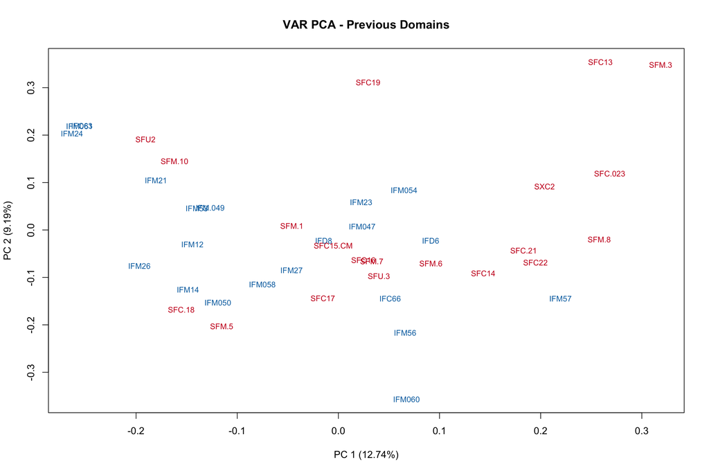

```r
plotPCA(cpm(x_domains, normalized.lib.sizes = TRUE, log = T, prior.count = 0.5),
    col = colors[categories], cex = 0.8, isLog = TRUE)
title("VAR PCA - Previous Domains")
```

## Investigate differential expression

```r
colData <- data.frame(disease = categories)
rownames(colData) <- colnames(x_domains$counts)
dds_dom <- DESeqDataSetFromMatrix(countData = x_domains$counts, colData = colData,
    design = ~disease)
dds_dom <- estimateSizeFactors(dds_dom)
dds_dom <- DESeq(dds_dom)
res <- results(dds_dom, contrast = c("disease", "S", "I"), pAdjustMethod = "BH")
summary(res, alpha = 0.05)
```

```
##
## out of 149 with nonzero total read count
## adjusted p-value < 0.05
## LFC > 0 (up)     : 16, 11%
## LFC < 0 (down)   : 4, 2.7%
## outliers [1]     : 0, 0%
## low counts [2]   : 0, 0%
## (mean count < 0)
## [1] see 'cooksCutoff' argument of ?results
## [2] see 'independentFiltering' argument of ?results
```

## A heatmap of the Up-regulated domains

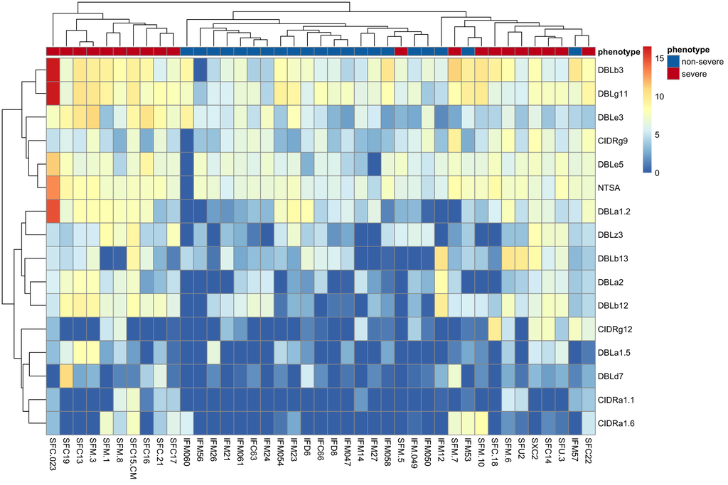

```r
res_domains <- res
resOrdered <- res_domains[order(res_domains$padj), ]
resSig <- subset(resOrdered, padj < 0.05)

resSigLFC <- data.frame(subset(resSig, log2FoldChange > 0))

select <- order(rowMeans(counts(dds_dom, normalized = TRUE)), decreasing = TRUE)

nt <- normTransform(dds_dom)
log2.norm.counts <- assay(nt)[select, ]
log2.norm.counts <- assay(nt)[rownames(nt) %in% rownames(resSigLFC), ]
annotData <- colData

disease <- colors
names(disease) <- c("non-severe", "severe")
anno_colors <- list(phenotype = disease)
annotData$phenotype[annotData$disease == "I"] <- "non-severe"
annotData$phenotype[annotData$disease == "S"] <- "severe"
# annotData <- annotData[annotData$disease=='S',]
annotData$disease <- NULL
pheatmap(log2.norm.counts, cluster_rows = TRUE, show_rownames = TRUE, cluster_cols = TRUE,
    annotation_col = annotData, annotation_colors = anno_colors)
```

## Boxplot of NTSA and NTSB domains

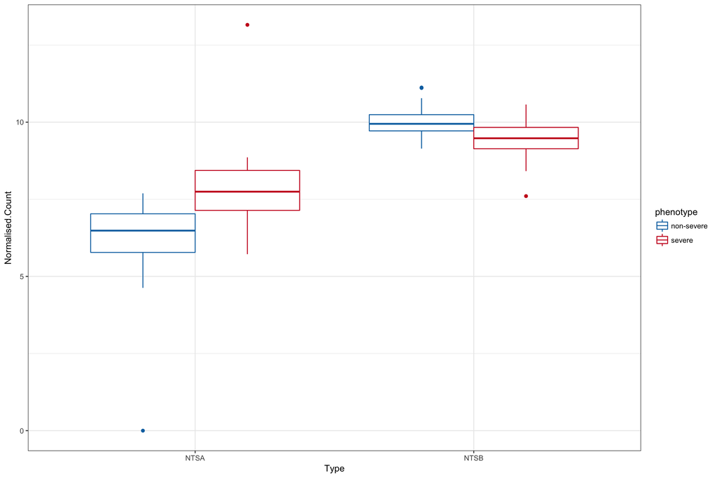

```r
setwd(wd)

select <- order(rowMeans(counts(dds_dom, normalized = TRUE)), decreasing = TRUE)

nt <- normTransform(dds_dom)
log2.norm.counts <- assay(nt)[select, ]
log2.norm.counts <- assay(nt)[rownames(nt) %in% c("NTSA", "NTSB"), ]

normCounts <- data.frame(t(log2.norm.counts))
normCounts$Sample <- rownames(normCounts)
normCounts$phenotype[as.factor(substring(rownames(normCounts), 1, 1)) == "S"] <- "severe"
normCounts$phenotype[as.factor(substring(rownames(normCounts), 1, 1)) == "I"] <- "non-severe"
normCounts <- melt(normCounts, id.vars = c("Sample", "phenotype"), variable.name = "Type",
    value.name = "Normalised.Count")

gg <- ggplot(normCounts, aes(x = Type, y = Normalised.Count, colour = phenotype))
# gg <- gg + geom_point(position=position_jitter(w=0.1,h=0))
gg <- gg + geom_boxplot()
gg <- gg + theme_bw()
gg <- gg + scale_colour_manual(values = colors)
gg
```

## Get clusters

Hierarchical clustering is performed by iteratively running **usearch** at identity levels 0.97,0.95,0.9,0.85,0.8,0.75,0.7,0.65,0.6,0.5 with the command

*usearch -cluster_fast input.fasta -sort length -wordlength 2 -fulldp -maxaccepts 0 -maxrejects 0 -alpha aa -mincols -id i -centroids out.fasta -uc clusters.uc*

This was chosen as it effectively dealt with fragments of domains. The method is **not** guaranteed to produce clusters where every sequence in the cluster is within the identity threshold of the centroid.

```r
setwd(wd)
clusters <- read.csv("./data/NTS_DBL_CIDR_seperate_assembly_domains_PreProcessed_hierarchical_clusters.csv")

stopifnot(nrow(dom_counts$counts) == nrow(clusters))

dom_counts_clusters <- merge(dom_counts$counts, clusters, by.x = 0, by.y = "Transcript")
```

## Create hierarchical structure

Starting with no clustering, individual domain counts are combined at the different hierarchical clustering levels.

```r
setwd(wd)

# first create an edgelist
edges <- list()
edges <- rbind(edges, cbind("root", paste(as.character(clusters[, 2]), colnames(clusters)[2],
    sep = "_")))
for (j in 3:(ncol(clusters))) {
    edges <- rbind(edges, cbind(paste(as.character(clusters[, j - 1]), colnames(clusters)[j -
        1], sep = "_"), paste(as.character(clusters[, j]), colnames(clusters)[j],
        sep = "_")))
}
edges <- edges[!duplicated(edges), ]
edges <- apply(as.matrix(edges), 2, as.character)

# now sum counts at the different clustering heights
results <- data.frame()
pca.df <- data.frame()
all_clusters.matrix <- data.frame()
for (c in colnames(clusters)[2:(ncol(clusters))]) {
    # reduce matrix to cluster at level c
    dom_counts_clusters.dt <- data.table(dom_counts_clusters)
    dom_counts_clusters.dt <- dom_counts_clusters.dt[, lapply(.SD, sum, na.rm = TRUE),
        by = c, .SDcols = colnames(dom_counts_clusters)[2:42]]

    dom_counts_clusters.matrix <- as.matrix(dom_counts_clusters.dt)
    dom_counts_clusters.matrix <- dom_counts_clusters.matrix[, 2:ncol(dom_counts_clusters.matrix)]
    rownames(dom_counts_clusters.matrix) <- paste(dom_counts_clusters.dt[[1]],
        c, sep = "_")
    all_clusters.matrix <- rbind(all_clusters.matrix, dom_counts_clusters.matrix)

    # generate points for PCA
    dgePCA <- DGEList(counts = dom_counts_clusters.matrix)
    colData <- data.frame(disease = as.factor(substring(colnames(dom_counts_clusters.matrix),
        1, 1)))
    rownames(colData) <- rownames(dgePCA$samples)
    ddsPCA <- DESeqDataSetFromMatrix(countData = dgePCA$counts  #dom_counts_clusters.matrix
, colData = colData, design = ~disease)
    cts <- counts(ddsPCA)
    geoMeans <- apply(cts, 1, function(row) if (all(row == 0))
        0 else exp(mean(log(row[row != 0]))))
    ddsPCA <- estimateSizeFactors(ddsPCA, geoMeans = geoMeans)
    pca <- plotPCA(varianceStabilizingTransformation(ddsPCA), intgroup = c("disease"),
        returnData = TRUE)
    pca$level <- c
    pca.df <- rbind(pca.df, pca)
}
```

## PCA plots at different levels

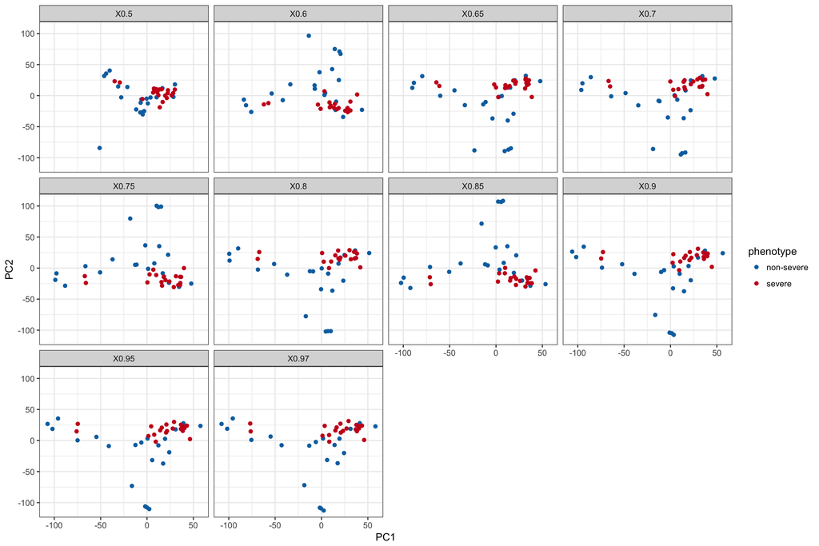

```r
setwd(wd)
pca.df$phenotype[pca.df$disease == "S"] <- "severe"
pca.df$phenotype[pca.df$disease == "I"] <- "non-severe"
gg <- ggplot(pca.df, aes(PC1, PC2, color = phenotype)) + scale_color_manual(values = colors)
# gg <- gg + geom_text(aes(label=name))
gg <- gg + geom_point()
gg <- gg + facet_wrap(~level)
gg <- gg + theme_bw()
gg
```

## A PCA plot of normalised counts for domains clustered at 50% identity

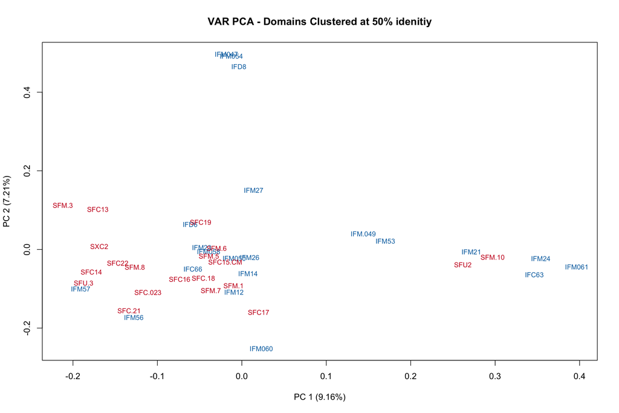

```r
setwd(wd)

dom_counts_clusters.dt <- data.table(dom_counts_clusters)
dom_counts_clusters.dt <- dom_counts_clusters.dt[, lapply(.SD, sum, na.rm = TRUE),
    by = "X0.5", .SDcols = colnames(dom_counts_clusters)[2:42]]

dom_counts_clusters.matrix <- as.matrix(dom_counts_clusters.dt)
dom_counts_clusters.matrix <- dom_counts_clusters.matrix[, 2:ncol(dom_counts_clusters.matrix)]
rownames(dom_counts_clusters.matrix) <- paste(dom_counts_clusters.dt[[1]], c,
    sep = "_")

# generate points for PCA
my_domains <- DGEList(counts = dom_counts_clusters.matrix)
my_domains <- calcNormFactors(my_domains, method = "RLE")
plotPCA(cpm(my_domains, normalized.lib.sizes = TRUE, log = T, prior.count = 0.5),
    col = colors[categories], cex = 0.8, isLog = TRUE)
title("VAR PCA - Domains Clustered at 50% idenitiy")
```

## Differential expression testing

First, to speed up computation and focus on only the most interesting domain clusters we remove those with less than 15 reads per million which appear in less than 5 samples.

```r
setwd(wd)

dge_clust <- DGEList(counts = as.matrix(all_clusters.matrix))

# create design matrix
colData <- data.frame(disease = as.factor(substring(rownames(dge_clust$samples),
    1, 1)))
rownames(colData) <- rownames(dge_clust$samples)

cpm(10, mean(dge_clust$samples$lib.size))
```

```
##         [,1]
## [1,] 15.5446
```

```r
keep <- rowSums(cpm(dge_clust) > 15) >= 5
dge_clust <- dge_clust[keep, , keep.lib.sizes = FALSE]
```

DESeq2 is now run with default parameters using the Benjamini-Yeukatelli procedure for multiple testing correction. We only take one cluster from each path through the tree (root to leaf) and thus overall we are more conservative than conventional Benjamini-Yeukatelli.

```r
setwd(wd)

# create DESeq2 dataset
dds <- DESeqDataSetFromMatrix(countData = dge_clust$counts, colData = colData,
    design = ~disease)

# estimate size factors
dds <- estimateSizeFactors(dds)

# run DESeq2 pipeline
dds <- DESeq(dds)
results <- results(dds, contrast = c("disease", "S", "I"), pAdjustMethod = "BY")
summary(results, alpha = 0.05)
```

```
##
## out of 6566 with nonzero total read count
## adjusted p-value < 0.05
## LFC > 0 (up)     : 80, 1.2%
## LFC < 0 (down)   : 272, 4.1%
## outliers [1]     : 0, 0%
## low counts [2]   : 507, 7.7%
## (mean count < 1)
## [1] see 'cooksCutoff' argument of ?results
## [2] see 'independentFiltering' argument of ?results
```

Match up p-values with edges in the tree structure and plot trees that have a significant node.

```r
setwd(wd)

Sig <- results[!is.na(results$padj), ]
Sig <- Sig[Sig$padj < 0.05, ]

tree <- graph.edgelist(edges)

naNodes <- V(tree)$name[!(V(tree)$name %in% rownames(results))]
na1s = rep(1, length(naNodes))

unadjp <- c(na1s, results$pvalue)
adjp <- c(rep(NA, length(naNodes)), results$padj)
names(unadjp) <- c(naNodes, rownames(results))
names(adjp) <- c(naNodes, rownames(results))


if (!all(names(unadjp) %in% unique(as.vector(edges)))) {
    stop("Names of elements in unadjp do not match names of tree nodes")
}
if (!all(unique(as.vector(edges)) %in% names(unadjp))) {
    stop("Names of elements in unadjp do not match names of tree nodes")
}

p.vals <- data.frame(unadjp, adjp = adjp)
rownames(p.vals) <- names(unadjp)

cluster_names <- clusters
for (i in 2:ncol(clusters)) {
    cluster_names[, i] <- paste(as.character(cluster_names[, i]), colnames(clusters)[i],
        sep = "_")
}
```

## Functions to explore the tree

These function return the ancestors and children of a given node in the hierarchical tree.

```r
setwd(wd)

# return the children of a node
get_children <- function(node, edges) {
    if (is.null(node)) {
        return(NULL)
    }
    tree.el.tmp <- data.frame(parent = edges[, 1], child = edges[, 2], stringsAsFactors = F)
    children <- tree.el.tmp[which(tree.el.tmp$parent == node), "child"]
    children <- unlist(c(children, lapply(children, get_children, edges)))
    return(children)
}

# return the anscestors of a node
get_parents <- function(node, edges) {
    if (is.null(node)) {
        return(NULL)
    }
    tree.el.tmp <- data.frame(parent = edges[, 1], child = edges[, 2], stringsAsFactors = F)
    parent <- tree.el.tmp[which(tree.el.tmp$child == node), "parent"]
    parent <- unlist(c(parent, lapply(parent, get_parents, edges)))
    return(parent)
}

# plot the subtree of a node
plot_tree <- function(node, edges, p.vals, return_script = FALSE) {
    tree <- graph.edgelist(edges)
    ancestors <- get_parents(node, edges)
    root <- ancestors[length(ancestors) - 1]  #choose root one level below root of entire tree
    if (ancestors[1] == "root") {
        root <- node
    }

    keep <- c(get_children(root, edges), root)
    newTree <- induced.subgraph(tree, vids = V(tree)[V(tree)$name %in% keep])
    p.vals <- p.vals[rownames(p.vals) %in% V(newTree)$name, ]
    p.vals <- p.vals[match(unique(as.vector(t(get.edgelist(newTree)))), rownames(p.vals)),
        ]

    hyp.tree <- new("hypothesesTree", tree = get.edgelist(newTree), p.vals = p.vals,
        alpha = 0.05)

    plot(hyp.tree, adjust = TRUE, return_script = return_script)
}
```

## Get significant nodes in trees

From those nodes that are found to be significant after multiple testing correction we keep only the most signifcant from one path through the tree. That is if a node has an ancestor or child that has a smaller p-value, it will not be considered. This is achieved by iteratively selecting the most significant node and removing it’s ancestors and children from the list of signifcant nodes.

```r
setwd(wd)

tempSig <- Sig
tempSig$cluster <- as.numeric(gsub(".*_X", "", rownames(tempSig)))
tempSig <- tempSig[order(tempSig$cluster), ]
SigFilteredResults <- data.frame()
while (nrow(tempSig) > 0) {
    trow <- tempSig[which.min(tempSig$padj), ]
    SigFilteredResults <- rbind(SigFilteredResults, trow)
    t <- rownames(trow)
    tChildren <- get_children(t, edges)
    tParents <- get_parents(t, edges)
    tempSig <- tempSig[!(rownames(tempSig) %in% c(t, tChildren, tParents)),
        ]
    tempSig <- tempSig[order(tempSig$cluster), ]
}

resUp <- SigFilteredResults[SigFilteredResults$log2FoldChange > 0, ]
resDown <- SigFilteredResults[SigFilteredResults$log2FoldChange < 0, ]
```

Overall we have found 70 significantly DE clusters of which 15 are up-regulated.

Update final results to include information on the transcripts that contain them

```r
# Collect sequence labels for each cluster
final <- data.frame(SigFilteredResults)
sig_clusters <- as.numeric(gsub("_.*", "", rownames(SigFilteredResults)))
levels <- gsub(".*_", "", rownames(SigFilteredResults))
significantClusters <- list()
for (i in 1:length(levels)) {
    significantClusters[[i]] <- clusters[clusters[, colnames(clusters) == levels[i]] ==
        sig_clusters[i], ]$Transcript
}
final$sequences <- I(significantClusters)

getDomain <- function(x) {
    x <- x[[1]][1]
    x <- toString(x)
    x <- strsplit(x, "_")
    x <- x[[1]]
    x <- x[length(x) - 1]
    return(x)
}
cluster_domain_type <- unlist(lapply(final$sequences, getDomain))
names(cluster_domain_type) <- rownames(final)
```

## Clustering significant domains based on co-expression

```r
# expression <- cpm(dge_clust, normalized.lib.sizes=TRUE,
# log=TRUE)[rownames(dge_clust) %in% rownames(resUp),]
select <- order(rowMeans(counts(dds, normalized = TRUE)), decreasing = TRUE)

nt <- normTransform(dds)
expression <- assay(nt)[rownames(nt) %in% rownames(resUp), ]

dissim = dist(expression)
dendro = hclust(dissim, method = "complete")

AutoColor = NULL
for (deepSplit in 0:3) AutoColor = cbind(AutoColor, labels2colors(cutreeDynamic(dendro = dendro,
    minClusterSize = 2, cutHeight = NULL, method = "hybrid", deepSplit = deepSplit,
    distM = as.matrix(dissim))))
```

```
##  ..cutHeight not given, setting it to 32.1  ===>  99% of the (truncated) height range in dendro.
##  ..done.
##  ..cutHeight not given, setting it to 32.1  ===>  99% of the (truncated) height range in dendro.
##  ..done.
##  ..cutHeight not given, setting it to 32.1  ===>  99% of the (truncated) height range in dendro.
##  ..done.
##  ..cutHeight not given, setting it to 32.1  ===>  99% of the (truncated) height range in dendro.
##  ..done.
```

```r
AutoLabels = paste("Hybrid 'auto': dS =", c(0:3))

cut <- cutreeDynamic(dendro = dendro, minClusterSize = 2, cutHeight = NULL,
    method = "hybrid", deepSplit = 0, distM = as.matrix(dissim))
```

```
##  ..cutHeight not given, setting it to 32.1  ===>  99% of the (truncated) height range in dendro.
##  ..done.
```

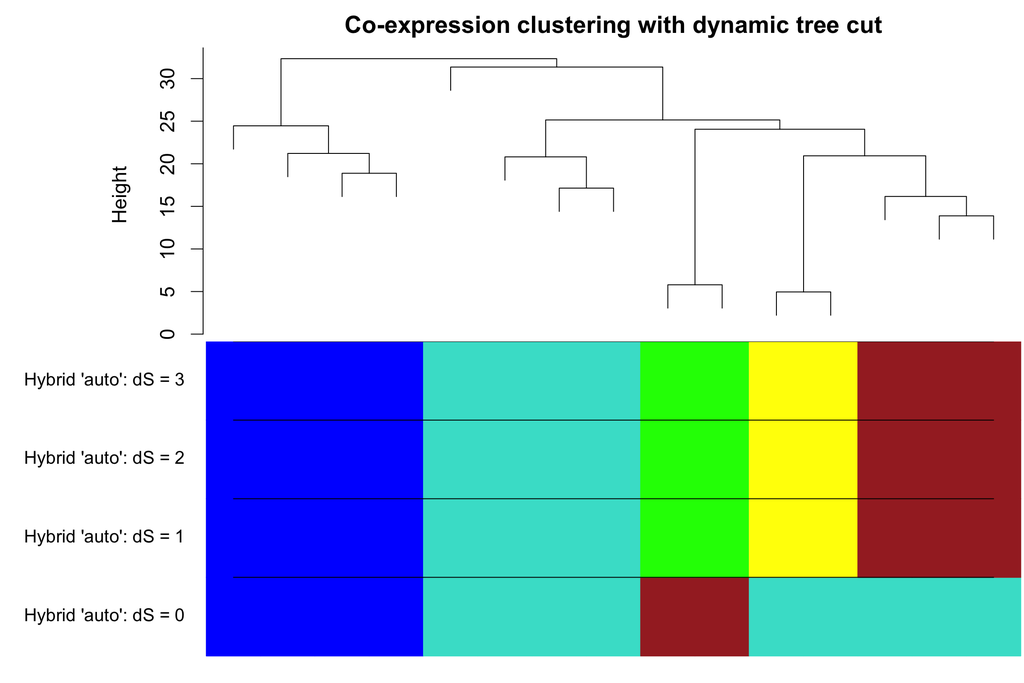

```r
rowLabels <- dendro$labels
# rowLabels <- rowLabels[dendro$order]
rowsAnnot <- data.frame(group = labels2colors(cut))
rownames(rowsAnnot) <- rowLabels


par(mfrow = c(2, 1))
par(cex = 1.4)
par(mar = c(0, 8.5, 2, 0))
plot(dendro, labels = F, main = "Co-expression clustering with dynamic tree cut",
    sub = "", xlab = "")
par(mar = c(1, 8.5, 0, 0))
plotHclustColors(dendro, AutoColor, AutoLabels, main = "")
```

## Heatmap of up-regulated clusters

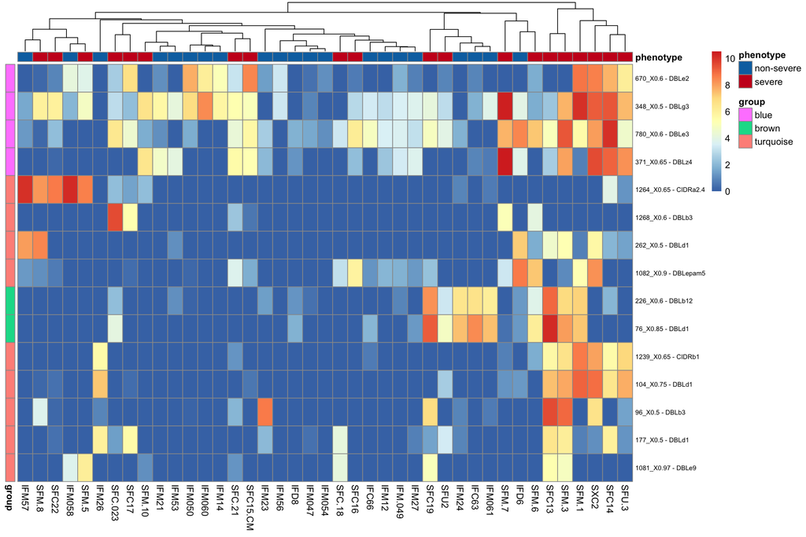

```r
setwd(wd)

select <- order(rowMeans(counts(dds, normalized = TRUE)), decreasing = TRUE)

nt <- normTransform(dds)
log2.norm.counts <- assay(nt)[select, ]
log2.norm.counts <- assay(nt)[rownames(nt) %in% rownames(resUp), ]
annotData <- colData

disease <- colors
names(disease) <- c("non-severe", "severe")
anno_colors <- list(phenotype = disease)
annotData$phenotype[annotData$disease == "I"] <- "non-severe"
annotData$phenotype[annotData$disease == "S"] <- "severe"
annotData$disease <- NULL

log2.norm.counts <- log2.norm.counts[dendro$order, ]
pheatmap(log2.norm.counts, cluster_rows = FALSE, show_rownames = TRUE, cluster_cols = TRUE,
    annotation_col = annotData, annotation_colors = anno_colors, clustering_method = "complete",
    cutree_rows = 9, labels_row = paste(rownames(log2.norm.counts), cluster_domain_type[rownames(log2.norm.counts)],
        sep = " - "), annotation_row = rowsAnnot, fontsize_row = 7)
```

## Heatmap of down-regulated clusters

```r
setwd(wd)

nt <- normTransform(dds)
expression <- assay(nt)[rownames(nt) %in% rownames(resDown), ]
dissim = dist(expression)
dendro = hclust(dissim, method = "complete")
cut <- cutreeDynamic(dendro = dendro, minClusterSize = 2, cutHeight = NULL,
    method = "hybrid", deepSplit = 0, distM = as.matrix(dissim))
```

```
##  ..cutHeight not given, setting it to 34.3  ===>  99% of the (truncated) height range in dendro.
##  ..done.
```

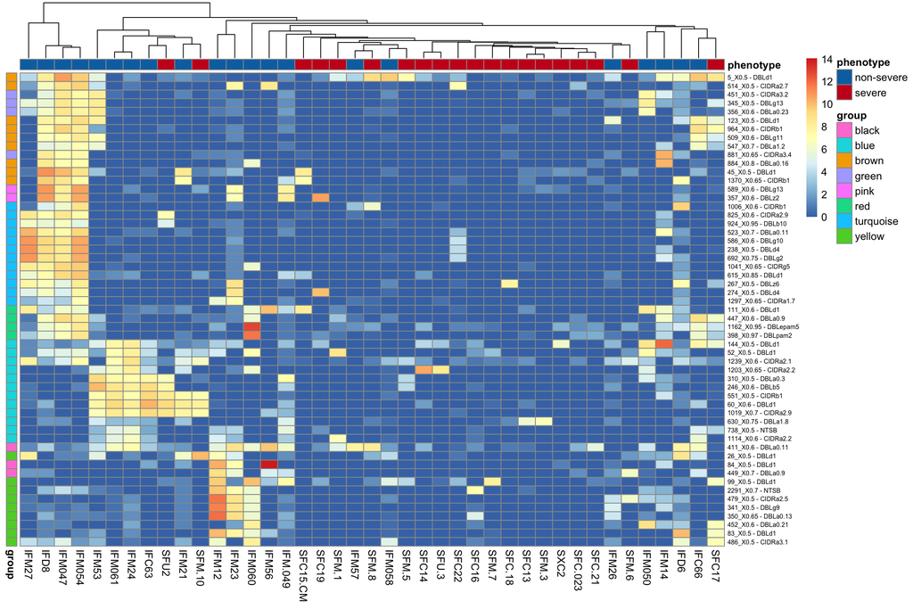

```r
rowLabels <- dendro$labels
rowsAnnot <- data.frame(group = labels2colors(cut))
rownames(rowsAnnot) <- rowLabels

select <- order(rowMeans(counts(dds, normalized = TRUE)), decreasing = TRUE)

nt <- normTransform(dds)
log2.norm.counts <- assay(nt)[select, ]
log2.norm.counts <- assay(nt)[rownames(nt) %in% rownames(resDown), ]
annotData <- colData

disease <- colors
names(disease) <- c("non-severe", "severe")
anno_colors <- list(phenotype = disease)
annotData$phenotype[annotData$disease == "I"] <- "non-severe"
annotData$phenotype[annotData$disease == "S"] <- "severe"
annotData$disease <- NULL

log2.norm.counts <- log2.norm.counts[dendro$order, ]
pheatmap(log2.norm.counts, cluster_rows = FALSE, show_rownames = TRUE, cluster_cols = TRUE,
    annotation_col = annotData, annotation_colors = anno_colors, clustering_method = "complete",
    cutree_rows = 10, labels_row = paste(rownames(log2.norm.counts), cluster_domain_type[rownames(log2.norm.counts)],
        sep = " - "), annotation_row = rowsAnnot, fontsize_row = 6)
```

## PCA plot plot of significant clusters

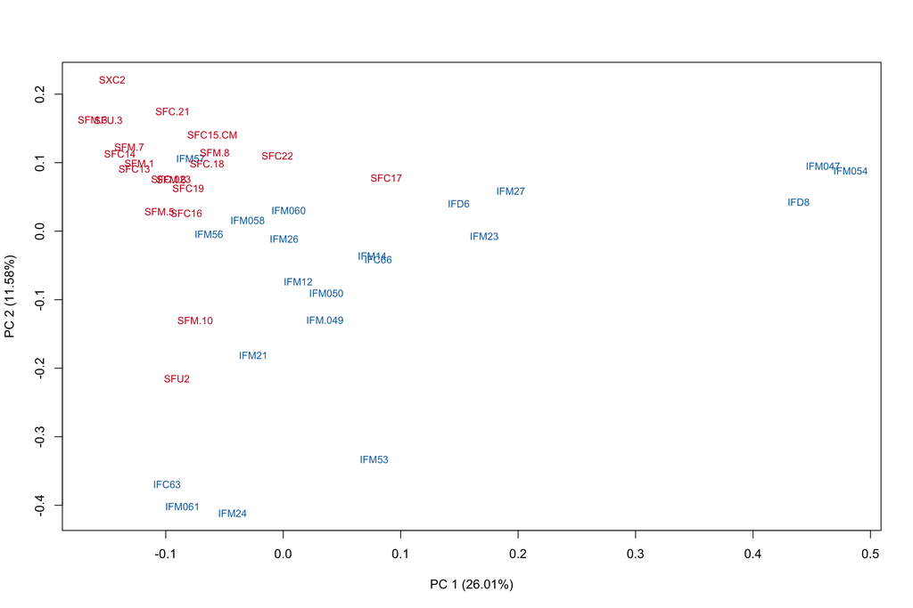

```r
setwd(wd)
plotPCA(cpm(dge_clust, normalized.lib.sizes = TRUE, log = T)[rownames(dge_clust) %in%
    rownames(SigFilteredResults), ], col = colors[colData$disease], cex = 0.8,
    isLog = TRUE)
```

## Table of results

```r
setwd(wd)

# Now print the table
final$padj <- format(final$padj, scientific = TRUE, digits = 3)
final$pvalue <- format(final$pvalue, scientific = TRUE, digits = 3)
final$sequences <- unlist(lapply(final$sequences, paste, collapse = ","))
kable(final, digits = 3)
```

|  | baseMean | log2FoldChange | lfcSE | stat | pvalue | padj | cluster | sequences |
| --- | --- | --- | --- | --- | --- | --- | --- | --- |
| 104_X0.75 | 42.908 | 8.501 | 1.325 | 6.418 | 1.38e-10 | 1.30e-06 | 0.75 | SFC13_S23_L002_Contig2454_frame_-2_DBLd1_domNum3,SFM-3_S12_L001_Contig1763_frame_2_DBLd1_domNum3,IFM26_S8_Contig337_frame_3_DBLd1_domNum3,SXC2_S4_L001_Contig1910_frame_-2_DBLd1_domNum4,SFC14_S17_L001_… |
| 345_X0.5 | 30.612 | -7.922 | 1.262 | -6.275 | 3.49e-10 | 2.46e-06 | 0.50 | IFD8_S2_Contig654_frame_-3_DBLg13_domNum1,IFM050_S11_Contig3785_frame_-2_DBLg13_domNum1,IFM054_S12_Contig1100_frame_-2_DBLg13_domNum2,IFM27_S9_Contig574_frm3_orf0_DBLg13_domNum1,IFM050_S11_Contig2529_… |
| 780_X0.6 | 69.816 | 4.740 | 0.777 | 6.102 | 1.05e-09 | 4.91e-06 | 0.60 | SFM-1_S11_L001_Contig2051_frame_-3_DBLe3_domNum1,IFD6_S1_Contig352_frame_3_DBLe10_domNum3,IFC66_S31_L002_Contig1788_frame_2_DBLe10_domNum2,SFC-023_S32_L002_Contig807_frame_3_DBLe10_domNum1,SFM-3_S12_L… |
| 350_X0.65 | 14.142 | -8.245 | 1.369 | -6.023 | 1.72e-09 | 5.08e-06 | 0.65 | IFM23_S4_Contig695_frame_-2_DBLa0.13_domNum2,IFM12_S16_Contig844_frame_-2_DBLa0.13_domNum2 |
| 479_X0.5 | 13.923 | -8.171 | 1.390 | -5.877 | 4.18e-09 | 8.12e-06 | 0.50 | SFM-6_S3_L001_Contig2001_frame_-2_CIDRa2.5_domNum1,IFM12_S16_Contig844_frame_-2_CIDRa2.9_domNum3,IFM23_S4_Contig695_frame_-2_CIDRa2.9_domNum3 |
| 341_X0.5 | 13.517 | -7.544 | 1.341 | -5.625 | 1.85e-08 | 2.54e-05 | 0.50 | IFM12_S16_Contig851_frame_-3_DBLg9_domNum4,IFM26_S8_Contig201_frame_1_DBLg10_domNum1,IFM23_S4_Contig695_frame_-2_DBLg9_domNum7 |
| 111_X0.6 | 21.718 | -6.191 | 1.099 | -5.634 | 1.76e-08 | 2.54e-05 | 0.60 | IFM054_S12_Contig1093_frame_1_DBLd1_domNum1,IFM27_S9_Contig576_frame_2_DBLd1_domNum1,IFM27_S9_1776_soapGraphK61_frame_-2_DBLd1_domNum1,SFC15-CM_S29_L002_Contig1972_frame_2_DBLd1_domNum2,IFM56_S15_Cont… |
| 447_X0.6 | 39.850 | -6.302 | 1.143 | -5.512 | 3.55e-08 | 3.91e-05 | 0.60 | IFM047_S10_Contig1232_frame_-3_DBLa0.9_domNum2,SFC17_S7_L001_Contig1172_frm-3_orf6_DBLa0.9_domNum2,SFC17_S7_L001_Contig2016_frame_-3_DBLa0.9_domNum1,IFM054_S12_Contig995_frame_-1_DBLa0.9_domNum1,IFM04… |
| 486_X0.5 | 12.104 | -6.318 | 1.154 | -5.473 | 4.43e-08 | 4.80e-05 | 0.50 | IFM12_S16_Contig843_frm2_orf3_CIDRa3.1_domNum3,SFC17_S7_L001_Contig2004_frame_2_CIDRa3.3_domNum1,IFM047_S10_Contig1226_frm-1_orf6_CIDRa3.3_domNum2,IFM058_S13_Contig1030_frame_3_CIDRa3.1_domNum2 |
| 123_X0.5 | 23.727 | -8.239 | 1.564 | -5.268 | 1.38e-07 | 1.38e-04 | 0.50 | IFM047_S10_Contig953_frame_3_DBLd1_domNum2,IFM054_S12_Contig1101_frame_1_DBLd1_domNum2,IFM26_S8_Contig647_frame_3_DBLd1_domNum1,IFM53_S14_L001_Contig2723_frame_2_DBLd1_domNum2,IFD8_S2_Contig884_frame_… |
| 523_X0.7 | 13.017 | -7.828 | 1.496 | -5.234 | 1.66e-07 | 1.46e-04 | 0.70 | SFC22_S9_L001_Contig3169_frame_3_DBLa0.11_domNum2,IFM054_S12_Contig880_frame_3_DBLa0.11_domNum2,IFM047_S10_Contig1234_frame_-1_DBLa0.11_domNum1,IFM27_S9_Contig420_frm1_orf3_DBLa0.11_domNum2,IFD8_S2_Co… |
| 60_X0.6 | 19.360 | -6.443 | 1.260 | -5.114 | 3.15e-07 | 2.43e-04 | 0.60 | IFM061_S15_Contig1009_frame_1_DBLd1_domNum3,IFM21_S3_Contig807_frm3_orf3_DBLd1_domNum2,IFM53_S14_L001_Contig2724_frame_-3_DBLd1_domNum3,IFM24_S5_Contig987_frame_-1_DBLd1_domNum3,SFM-10_S1_L001_Contig2… |
| 692_X0.75 | 19.457 | -7.887 | 1.599 | -4.931 | 8.17e-07 | 5.61e-04 | 0.75 | SFC22_S9_L001_Contig1331_frame_1_DBLg2_domNum1,IFM27_S9_Contig420_frm1_orf3_DBLg2_domNum4,IFM047_S10_Contig1675_frame_-3_DBLg2_domNum3,IFM054_S12_Contig138_frame_1_DBLg2_domNum3,IFD8_S2_Contig1050_fra… |
| 551_X0.5 | 11.178 | -7.262 | 1.487 | -4.884 | 1.04e-06 | 6.37e-04 | 0.50 | IFC63_S16_L001_Contig1916_frame_1_CIDRb1_domNum4,IFM061_S15_Contig1009_frame_1_CIDRb1_domNum4,SFU2_S5_L001_Contig1892_frame_1_CIDRb1_domNum3,SFM-10_S1_L001_Contig2583_frame_-2_CIDRb1_domNum4,IFM21_S3_… |
| 84_X0.5 | 34.362 | -7.677 | 1.580 | -4.859 | 1.18e-06 | 7.06e-04 | 0.50 | IFM56_S15_Contig1236_frame_-1_DBLd1_domNum4,IFM12_S16_Contig852_frame_-1_DBLd1_domNum4,IFM23_S4_Contig101_frm3_orf40_DBLd1_domNum2 |
| 45_X0.5 | 19.670 | -5.601 | 1.166 | -4.803 | 1.57e-06 | 8.99e-04 | 0.50 | IFM21_S3_Contig614_frame_2_DBLd1_domNum1,IFM054_S12_Contig1098_frame_-3_DBLd1_domNum2,IFM21_S3_Contig1058_frame_-2_DBLd1_domNum1,SFC15-CM_S29_L002_Contig1970_frame_-2_DBLd1_domNum1,IFM047_S10_Contig98… |
| 411_X0.6 | 59.491 | -4.103 | 0.875 | -4.688 | 2.76e-06 | 1.57e-03 | 0.60 | SFC-21_S22_L002_Contig1589_frame_3_DBLa0.11_domNum1,IFM57_S30_L002_Contig1547_frame_-1_DBLa0.10_domNum2,IFC66_S31_L002_Contig1574_frame_-3_DBLa0.10_domNum2,IFM56_S15_Contig1774_frame_-2_DBLa0.10_domNu… |
| 451_X0.5 | 10.454 | -6.190 | 1.325 | -4.673 | 2.96e-06 | 1.67e-03 | 0.50 | IFD8_S2_Contig647_frame_3_CIDRa3.2_domNum2,IFM050_S11_Contig3309_frame_-1_CIDRa3.4_domNum2,IFM050_S11_Contig3670_frame_2_CIDRa3.2_domNum1,IFM53_S14_L001_Contig2477_frame_1_CIDRa3.2_domNum3,IFM054_S12_… |
| 1239_X0.65 | 13.983 | 6.967 | 1.499 | 4.649 | 3.34e-06 | 1.74e-03 | 0.65 | SFM-3_S12_L001_Contig1763_frame_2_CIDRb1_domNum4,SFU-3_S21_L002_Contig2033_frame_-3_CIDRb1_domNum4,IFM26_S8_Contig554_frame_1_CIDRb1_domNum1,SFC13_S23_L002_Contig2145_frame_3_CIDRb1_domNum1,SXC2_S4_L0… |
| 83_X0.5 | 7.036 | -6.677 | 1.445 | -4.619 | 3.85e-06 | 1.90e-03 | 0.50 | IFM12_S16_Contig842_frame_1_DBLd1_domNum1,SFC17_S7_L001_Contig1973_frame_2_DBLd1_domNum1,IFM23_S4_Contig693_frame_1_DBLd1_domNum5,IFD6_S1_Contig745_frm1_orf15_DBLd1_domNum4,IFM23_S4_Contig694_frame_1_… |
| 310_X0.5 | 16.833 | -6.457 | 1.412 | -4.574 | 4.78e-06 | 2.28e-03 | 0.50 | IFM53_S14_L001_Contig2476_frm1_orf5_DBLa0.3_domNum2,IFC63_S16_L001_Contig1642_frame_1_DBLa0.3_domNum2,IFM24_S5_Contig829_frame_1_DBLa0.3_domNum2,IFM061_S15_Contig756_frame_2_DBLa0.3_domNum2,IFM-049_S6… |
| 1203_X0.65 | 6.704 | -6.483 | 1.419 | -4.568 | 4.93e-06 | 2.33e-03 | 0.65 | IFM53_S14_L001_Contig1645_frame_1_CIDRa2.2_domNum2,SFU-3_S21_L002_Contig2032_frame_-1_CIDRa2.2_domNum3,IFM24_S5_Contig857_frame_-3_CIDRa2.2_domNum3,IFC63_S16_L001_Contig1262_frame_1_CIDRa2.2_domNum1,S… |
| 398_X0.97 | 15.231 | -5.146 | 1.128 | -4.562 | 5.08e-06 | 2.38e-03 | 0.97 | IFD8_S2_Contig393_frame_-1_DBLpam2_domNum1,IFM060_S14_Contig343_frame_-1_DBLpam2_domNum1,IFM054_S12_Contig492_frame_1_DBLpam2_domNum3,IFM047_S10_Contig664_frm-2_orf1_DBLpam2_domNum3,SFC17_S7_L001_Cont… |
| 2291_X0.7 | 5.672 | -6.269 | 1.379 | -4.546 | 5.46e-06 | 2.42e-03 | 0.70 | IFM23_S4_Contig695_frame_-2_NTSB_domNum1,SFC16_S6_L001_4433_soapGraphK61_frame_1_NTSB_domNum1,IFM12_S16_Contig844_frame_-2_NTSB_domNum1,SFC16_S6_L001_Contig1630_frame_3_NTSB_domNum1 |
| 144_X0.5 | 28.202 | -4.235 | 0.942 | -4.497 | 6.90e-06 | 3.04e-03 | 0.50 | IFC66_S31_L002_5278_soapGraphK61_frame_-2_DBLd1_domNum2,SXC2_S4_L001_Contig1689_frame_-3_DBLd1_domNum1,IFC66_S31_L002_Contig1585_frame_-2_DBLd1_domNum2,SFC17_S7_L001_Contig2024_frame_-2_DBLd1_domNum5,… |
| 1114_X0.6 | 3.801 | -6.033 | 1.356 | -4.449 | 8.61e-06 | 3.70e-03 | 0.60 | IFM24_S5_Contig983_frm3_orf14_CIDRa2.2_domNum2,SFM-1_S11_L001_Contig1232_frame_3_CIDRa2.2_domNum2,IFM061_S15_Contig965_frame_3_CIDRa2.2_domNum2,SFM-1_S11_L001_5116_soapGraphK61_frame_-1_CIDRa2.2_domNu… |
| 357_X0.6 | 16.129 | -7.038 | 1.630 | -4.319 | 1.57e-05 | 6.39e-03 | 0.60 | IFM047_S10_Contig1674_frame_2_DBLz2_domNum4,IFM054_S12_Contig1103_frame_-3_DBLz2_domNum4,IFD8_S2_Contig1034_frame_2_DBLz2_domNum7,IFM23_S4_Contig650_frame_3_DBLz2_domNum5,IFM-049_S6_Contig41147_frm-3_… |
| 1019_X0.7 | 11.987 | -6.754 | 1.572 | -4.298 | 1.72e-05 | 6.69e-03 | 0.70 | IFM061_S15_Contig1009_frame_1_CIDRa2.9_domNum2,IFC63_S16_L001_Contig1916_frame_1_CIDRa2.9_domNum2,SFU2_S5_L001_Contig1883_frame_-1_CIDRa2.6_domNum2,IFM53_S14_L001_Contig2724_frame_-3_CIDRa2.9_domNum2,… |
| 738_X0.5 | 5.011 | -5.629 | 1.313 | -4.286 | 1.82e-05 | 7.01e-03 | 0.50 | IFM061_S15_Contig996_frame_1_NTSB_domNum1,IFC66_S31_L002_Contig1574_frame_-3_NTSB_domNum1,SFC17_S7_L001_Contig1981_frame_1_NTSB_domNum1,IFM-049_S6_Contig40827_frm-3_orf1_NTSB_domNum1,IFM12_S16_Contig5… |
| 26_X0.5 | 7.623 | -4.446 | 1.045 | -4.255 | 2.09e-05 | 8.01e-03 | 0.50 | IFC66_S31_L002_Contig1324_frame_1_DBLd1_domNum3,IFD6_S1_Contig941_frame_-2_DBLd1_domNum2,SFM-10_S1_L001_Contig1145_frm-1_orf0_DBLd1_domNum4,IFM12_S16_Contig533_frame_3_DBLd1_domNum3,IFM21_S3_Contig787… |
| 238_X0.5 | 21.657 | -7.137 | 1.706 | -4.183 | 2.87e-05 | 9.98e-03 | 0.50 | IFM047_S10_Contig1675_frame_-3_DBLd4_domNum4,IFM27_S9_Contig420_frm1_orf3_DBLd4_domNum5,IFM054_S12_Contig138_frame_1_DBLd4_domNum4,SFC22_S9_L001_Contig1331_frame_1_DBLd4_domNum2,IFD8_S2_Contig1050_fra… |
| 52_X0.5 | 22.400 | -4.484 | 1.082 | -4.143 | 3.42e-05 | 1.05e-02 | 0.50 | IFM061_S15_Contig323_frame_2_DBLd1_domNum4,IFM047_S10_Contig1381_frame_-2_DBLd1_domNum1,IFM24_S5_Contig819_frame_1_DBLd1_domNum3,SFM-1_S11_L001_Contig2078_frame_3_DBLd1_domNum3,IFM050_S11_Contig2893_f… |
| 547_X0.7 | 6.288 | -6.679 | 1.607 | -4.157 | 3.23e-05 | 1.05e-02 | 0.70 | IFM53_S14_L001_Contig2126_frame_1_DBLa1.2_domNum1,IFC66_S31_L002_Contig1010_frm1_orf7_DBLa1.7_domNum2,IFM054_S12_Contig1089_frame_-2_DBLa1.7_domNum2,SFC17_S7_L001_Contig1411_frame_2_DBLa1.2_domNum1,IF… |
| 177_X0.5 | 5.115 | 4.755 | 1.153 | 4.123 | 3.73e-05 | 1.14e-02 | 0.50 | SFM-3_S12_L001_Contig1674_frame_1_DBLd1_domNum1,SFC13_S23_L002_Contig2743_frame_3_DBLd1_domNum1,IFM26_S8_Contig436_frame_-3_DBLd1_domNum1,SFC17_S7_L001_Contig1992_frame_2_DBLd1_domNum1,IFM26_S8_Contig… |
| 356_X0.6 | 5.031 | -5.204 | 1.266 | -4.112 | 3.93e-05 | 1.19e-02 | 0.60 | IFM050_S11_Contig3776_frame_-1_DBLa0.23_domNum2,IFM054_S12_Contig904_frame_3_DBLa0.15_domNum2,IFM047_S10_Contig1244_frame_3_DBLa0.9_domNum2,IFM047_S10_Contig1435_frm-1_orf11_DBLa0.2_domNum1,IFM047_S10… |
| 1081_X0.97 | 4.440 | 6.270 | 1.525 | 4.110 | 3.95e-05 | 1.19e-02 | 0.97 | SFM-3_S12_L001_Contig669_frame_-1_DBLe9_domNum2,SFC13_S23_L002_Contig2734_frame_-1_DBLe9_domNum1,SFC19_S24_L002_Contig1154_frame_3_DBLe9_domNum1 |
| 514_X0.5 | 15.705 | -5.570 | 1.357 | -4.103 | 4.07e-05 | 1.22e-02 | 0.50 | IFM23_S4_Contig581_frame_1_CIDRa2.7_domNum3,IFM054_S12_Contig743_frame_-1_CIDRa2.3_domNum3,IFC66_S31_L002_Contig1324_frame_1_CIDRa2.7_domNum1,IFM047_S10_Contig1549_frm3_orf4_CIDRa2.3_domNum3,SFC22_S9_… |
| 452_X0.6 | 7.181 | -5.197 | 1.273 | -4.084 | 4.43e-05 | 1.32e-02 | 0.60 | IFM050_S11_18120_soapGraphK51_frame_1_DBLa0.21_domNum2,SFC17_S7_L001_5661_soapGraphK61_frame_-2_DBLa0.12_domNum2,SFC17_S7_L001_Contig1745_frame_-1_DBLa0.12_domNum2,IFM050_S11_8042_soapGraphK61_frame_3… |
| 1162_X0.95 | 15.852 | -4.106 | 1.010 | -4.065 | 4.81e-05 | 1.42e-02 | 0.95 | IFM047_S10_Contig664_frm-3_orf90_DBLepam5_domNum2,IFM054_S12_Contig557_frm1_orf0_DBLepam5_domNum2,IFC66_S31_L002_Contig1665_frame_-1_DBLepam5_domNum1,IFM060_S14_Contig239_frm3_orf0_DBLepam5_domNum1,SF… |
| 1082_X0.9 | 7.341 | 4.306 | 1.075 | 4.005 | 6.20e-05 | 1.80e-02 | 0.90 | IFD6_S1_Contig352_frame_3_DBLepam5_domNum2,SXC2_S4_L001_Contig610_frm-3_orf4_DBLepam5_domNum7,SFM-6_S3_L001_Contig662_frame_3_DBLepam5_domNum1,SFC16_S6_L001_Contig1398_frm2_orf17_DBLepam5_domNum3,SFM-… |
| 509_X0.6 | 5.676 | -6.491 | 1.630 | -3.982 | 6.82e-05 | 1.89e-02 | 0.60 | IFM047_S10_Contig1653_frame_-3_DBLg11_domNum1,IFD8_S2_Contig1038_frame_1_DBLg11_domNum1,IFM054_S12_Contig909_frame_1_DBLg11_domNum3,IFC66_S31_L002_Contig1010_frm1_orf7_DBLg11_domNum5,SFC17_S7_L001_560… |
| 1264_X0.65 | 10.111 | 6.037 | 1.524 | 3.961 | 7.47e-05 | 1.96e-02 | 0.65 | SFM-8_S8_L001_Contig3152_frame_2_CIDRa2.4_domNum2,SFM-8_S8_L001_10408_soapGraphK61_frame_-3_CIDRa2.4_domNum2,SFC22_S9_L001_Contig2837_frame_1_CIDRa2.4_domNum2,IFM57_S30_L002_Contig1705_frame_-3_CIDRa2… |
| 449_X0.7 | 3.200 | -5.316 | 1.347 | -3.947 | 7.92e-05 | 2.06e-02 | 0.70 | IFM-049_S6_Contig27552_frame_1_DBLa0.9_domNum1,SFM-6_S3_L001_Contig1750_frame_-3_DBLa0.9_domNum1,IFM12_S16_Contig852_frame_-1_DBLa0.9_domNum2 |
| 274_X0.5 | 3.976 | -6.242 | 1.589 | -3.928 | 8.57e-05 | 2.22e-02 | 0.50 | SFC19_S24_L002_Contig720_frm3_orf4_DBLd4_domNum5,IFM23_S4_Contig474_frame_2_DBLd8_domNum5,IFD8_S2_Contig853_frm3_orf6_DBLd8_domNum1,IFM047_S10_Contig1248_frame_-3_DBLd8_domNum1,IFD8_S2_Contig504_frame… |
| 924_X0.95 | 2.443 | -5.878 | 1.514 | -3.882 | 1.03e-04 | 2.64e-02 | 0.95 | IFM27_S9_Contig625_frame_-2_DBLb10_domNum1 |
| 586_X0.6 | 9.698 | -6.659 | 1.721 | -3.871 | 1.09e-04 | 2.66e-02 | 0.60 | IFD8_S2_Contig882_frame_-1_DBLg10_domNum2,IFM054_S12_Contig907_frame_1_DBLg10_domNum2,IFM047_S10_Contig1675_frame_-3_DBLg10_domNum6,SFC22_S9_L001_Contig2844_frm2_orf12_DBLg10_domNum2,IFM27_S9_Contig62… |
| 267_X0.5 | 19.460 | -5.373 | 1.410 | -3.810 | 1.39e-04 | 3.32e-02 | 0.50 | IFM047_S10_Contig918_frm2_orf0_DBLz6_domNum2,SFC-18_S20_L002_Contig1912_frame_-3_DBLz6_domNum1,IFM27_S9_Contig628_frame_-3_DBLz6_domNum2,IFD6_S1_Contig572_frame_2_DBLz6_domNum2,SFC-18_S20_L002_4632_so… |
| 99_X0.5 | 29.453 | -4.743 | 1.254 | -3.783 | 1.55e-04 | 3.47e-02 | 0.50 | SFC17_S7_L001_Contig1379_frame_-3_DBLd1_domNum3,IFM058_S13_Contig1074_frame_-3_DBLd1_domNum1,SFC22_S9_L001_Contig1894_frame_2_DBLd1_domNum1,SFM-7_S13_L001_Contig1892_frame_-2_DBLd1_domNum4,IFM-049_S6_… |
| 246_X0.6 | 6.775 | -5.386 | 1.427 | -3.775 | 1.60e-04 | 3.47e-02 | 0.60 | IFM061_S15_Contig380_frame_1_DBLb5_domNum2,IFM53_S14_L001_Contig2476_frm1_orf5_DBLb5_domNum4,IFC63_S16_L001_Contig1659_frame_-3_DBLb5_domNum2,IFM53_S14_L001_6722_soapGraphK61_frame_3_DBLb5_domNum2,IFM… |
| 1239_X0.6 | 16.209 | -3.198 | 0.847 | -3.774 | 1.61e-04 | 3.47e-02 | 0.60 | IFM061_S15_Contig1006_frame_-3_CIDRa2.1_domNum3,IFM050_S11_Contig2290_frame_-2_CIDRa2.1_domNum2,IFM24_S5_Contig119_frame_-2_CIDRa2.1_domNum3,IFM054_S12_Contig895_frame_2_CIDRa2.1_domNum3,IFM24_S5_Cont… |
| 589_X0.6 | 15.855 | -5.280 | 1.391 | -3.795 | 1.48e-04 | 3.47e-02 | 0.60 | IFM-049_S6_Contig41147_frm-3_orf14_DBLg13_domNum4,IFD8_S2_Contig1034_frame_2_DBLg13_domNum6,IFM054_S12_Contig1103_frame_-3_DBLg13_domNum3,IFM23_S4_Contig650_frame_3_DBLg13_domNum4,IFM047_S10_Contig167… |
| 1041_X0.65 | 7.667 | -6.121 | 1.618 | -3.784 | 1.55e-04 | 3.47e-02 | 0.65 | IFM047_S10_Contig1023_frame_3_CIDRg5_domNum2,IFM27_S9_1774_soapGraphK61_frame_1_CIDRg5_domNum2,IFM054_S12_Contig1093_frame_1_CIDRg5_domNum2,IFM27_S9_Contig576_frame_2_CIDRg5_domNum2,IFD8_S2_Contig823_… |
| 1297_X0.65 | 2.481 | -5.063 | 1.338 | -3.784 | 1.54e-04 | 3.47e-02 | 0.65 | IFM054_S12_2489_soapGraphK61_frame_3_CIDRa1.7_domNum2,IFM054_S12_Contig1008_frame_-2_CIDRa1.7_domNum2,IFM12_S16_Contig240_frame_2_CIDRa1.7_domNum3,IFM23_S4_Contig698_frm-1_orf23_CIDRa1.7_domNum2 |
| 884_X0.8 | 8.674 | -6.015 | 1.595 | -3.771 | 1.62e-04 | 3.47e-02 | 0.80 | IFM14_S7_Contig566_frm3_orf0_DBLa0.16_domNum1,IFM047_S10_Contig981_frame_3_DBLa0.16_domNum2,IFD8_S2_Contig1127_frame_1_DBLa0.16_domNum2,IFM14_S7_Contig566_frm1_orf11_DBLa0.16_domNum1,IFM054_S12_Contig… |
| 5_X0.5 | 79.092 | -3.620 | 0.965 | -3.750 | 1.77e-04 | 3.58e-02 | 0.50 | SFM-1_S11_L001_Contig1213_frame_-3_DBLd1_domNum1,IFM054_S12_Contig1096_frame_-2_DBLd1_domNum3,IFM047_S10_Contig1673_frame_-1_DBLd1_domNum2,IFM26_S8_Contig434_frame_-2_DBLd1_domNum1,IFC66_S31_L002_8427… |
| 825_X0.6 | 7.486 | -6.209 | 1.654 | -3.755 | 1.74e-04 | 3.58e-02 | 0.60 | IFD8_S2_Contig613_frm1_orf0_CIDRa2.9_domNum1,IFM047_S10_Contig1085_frame_3_CIDRa2.9_domNum2,IFM047_S10_4772_soapGraphK61_frame_1_CIDRa2.9_domNum3,IFM047_S10_Contig1010_frame_1_CIDRa2.9_domNum1,IFM054_… |
| 371_X0.65 | 52.047 | 4.203 | 1.120 | 3.752 | 1.75e-04 | 3.58e-02 | 0.65 | SFM-7_S13_L001_Contig1472_frame_-1_DBLz4_domNum4,SFU-3_S21_L002_Contig1467_frame_1_DBLz4_domNum5,SFC14_S17_L001_Contig2411_frm2_orf1_DBLz4_domNum7,SFM-10_S1_L001_Contig1166_frame_2_DBLz4_domNum1,SFC-2… |
| 615_X0.85 | 6.272 | -4.746 | 1.266 | -3.750 | 1.77e-04 | 3.58e-02 | 0.85 | IFM047_S10_Contig1549_frm3_orf4_DBLd1_domNum4,IFM054_S12_Contig520_frame_1_DBLd1_domNum2,IFD8_S2_Contig1121_frame_-1_DBLd1_domNum2 |
| 348_X0.5 | 123.134 | 3.051 | 0.817 | 3.736 | 1.87e-04 | 3.77e-02 | 0.50 | SFM-1_S11_L001_Contig1854_frame_1_DBLg3_domNum4,SFM-7_S13_L001_Contig933_frame_3_DBLg3_domNum3,SFC22_S9_L001_Contig3210_frame_3_DBLg4_domNum2,SXC2_S4_L001_Contig1018_frame_3_DBLg3_domNum1,SXC2_S4_L001… |
| 630_X0.75 | 2.212 | -4.075 | 1.093 | -3.726 | 1.94e-04 | 3.88e-02 | 0.75 | IFM53_S14_L001_Contig2114_frm1_orf0_DBLa1.8_domNum1,SFC13_S23_L002_Contig2737_frm-3_orf4_DBLa1.8_domNum2,IFM-049_S6_Contig16803_frame_-1_DBLa1.8_domNum1,SFM-3_S12_L001_Contig1087_frm-1_orf4_DBLa1.8_do… |
| 262_X0.5 | 2.860 | 5.208 | 1.399 | 3.723 | 1.97e-04 | 3.88e-02 | 0.50 | IFM57_S30_L002_Contig1715_frame_2_DBLd1_domNum1,SFC13_S23_L002_Contig2721_frame_3_DBLd1_domNum1,SXC2_S4_L001_8205_soapGraphK51_frame_-2_DBLd1_domNum1,SFM-3_S12_L001_Contig1998_frame_3_DBLd1_domNum1,IF… |
| 76_X0.85 | 13.474 | 4.646 | 1.250 | 3.717 | 2.02e-04 | 3.91e-02 | 0.85 | SFM-3_S12_L001_Contig2006_frame_-3_DBLd1_domNum4,SFC13_S23_L002_Contig1795_frame_-3_DBLd1_domNum6,SFM-1_S11_L001_Contig2077_frame_-3_DBLd1_domNum2,SFC19_S24_L002_Contig1569_frame_-3_DBLd1_domNum6,IFC6… |
| 881_X0.65 | 7.869 | -5.603 | 1.510 | -3.710 | 2.07e-04 | 3.94e-02 | 0.65 | IFD8_S2_Contig430_frame_-1_CIDRa3.4_domNum2,IFM14_S7_Contig491_frame_-2_CIDRa3.4_domNum2,IFM054_S12_Contig722_frm1_orf13_CIDRa3.4_domNum1,IFM054_S12_Contig722_frm3_orf0_CIDRa3.4_domNum2,IFM14_S7_Conti… |
| 226_X0.6 | 7.262 | 4.529 | 1.225 | 3.696 | 2.19e-04 | 4.05e-02 | 0.60 | IFM061_S15_8731_soapGraphK41_frame_1_DBLb12_domNum2,SFM-1_S11_L001_Contig1884_frm3_orf5_DBLb12_domNum4,SFC13_S23_L002_Contig1795_frame_-3_DBLb12_domNum4,IFM061_S15_Contig910_frame_2_DBLb12_domNum2,SFM… |
| 96_X0.5 | 5.421 | 5.170 | 1.410 | 3.667 | 2.45e-04 | 4.41e-02 | 0.50 | SFM-8_S8_L001_Contig3140_frame_-3_DBLb3_domNum1,SFM-3_S12_L001_Contig1068_frm1_orf6_DBLb3_domNum4,SFC19_S24_L002_Contig636_frame_2_DBLb1_domNum1,SXC2_S4_L001_Contig1305_frame_-2_DBLb3_domNum2,IFM23_S4… |
| 1006_X0.6 | 2.678 | -5.205 | 1.420 | -3.665 | 2.47e-04 | 4.41e-02 | 0.60 | IFM054_S12_Contig901_frame_3_CIDRb1_domNum1,IFM054_S12_Contig1091_frame_3_CIDRb1_domNum2,IFM57_S30_L002_Contig1295_frame_2_CIDRb1_domNum1,SFM-8_S8_L001_Contig3590_frame_2_CIDRb1_domNum3,IFM047_S10_Con… |
| 670_X0.6 | 41.745 | 3.872 | 1.066 | 3.633 | 2.81e-04 | 4.73e-02 | 0.60 | SXC2_S4_L001_Contig1912_frame_-3_DBLe2_domNum7,SFC14_S17_L001_Contig2402_frm-3_orf12_DBLe2_domNum4,SFM-1_S11_L001_Contig2101_frame_-1_DBLe2_domNum5,SFU-3_S21_L002_Contig1778_frame_3_DBLe2_domNum2,SFC1… |
| 1268_X0.6 | 2.281 | 5.507 | 1.524 | 3.613 | 3.02e-04 | 4.97e-02 | 0.60 | SFC-023_S32_L002_2405_soapGraphK61_frame_2_DBLb3_domNum1,SFC17_S7_L001_Contig2007_frame_1_DBLb9_domNum1,SFM-7_S13_L001_Contig2139_frame_3_DBLb9_domNum1,SFC-023_S32_L002_Contig1063_frame_1_DBLb3_domNum… |
| 964_X0.6 | 3.919 | -5.137 | 1.425 | -3.605 | 3.13e-04 | 5.00e-02 | 0.60 | IFC66_S31_L002_Contig1318_frame_1_CIDRb1_domNum1,IFC66_S31_L002_5302_soapGraphK61_frame_-2_CIDRb1_domNum2,SFC17_S7_L001_Contig2010_frame_3_CIDRb1_domNum2,IFC66_S31_L002_8427_soapGraphK51_frame_-3_CIDR… |
| 1370_X0.65 | 11.045 | -5.491 | 1.522 | -3.609 | 3.08e-04 | 5.00e-02 | 0.65 | IFD6_S1_Contig976_frame_3_CIDRb1_domNum3,IFM21_S3_Contig1058_frame_-2_CIDRb6_domNum2,IFM054_S12_Contig1090_frame_-2_CIDRb6_domNum1,IFD8_S2_Contig879_frame_-2_CIDRb6_domNum1,SFC15-CM_S29_L002_Contig197… |

## Create Tree Plots

```r
# writeTree <- function(node, directory, edges, p.vals){
# sink(paste(paste(directory,node,sep=''), '_tree.html', sep=''))
# cat(plot_tree(node, edges, p.vals, return_script=TRUE)) sink()
# closeAllConnections() # close(paste(paste(directory,node,sep='_'),
# '_tree.html')) } plot_tree('670_X0.6', edges, p.vals, return_script=F)
# writeTree('670_X0.6', '/home/users/allstaff/tonkin-hill.g/Dropbox/Var
# transcriptome manuscript/Figures/VAR differential analysis
# (4)/domainTrees/', edges, p.vals) lapply(rownames(final), writeTree,
# '/home/users/allstaff/tonkin-hill.g/var_differential_analysis/domain_level/tree_figures/',
# edges, p.vals)
```

## Create Dot Plots for Tree Diagrams

```r
# plotExpression <- function(cluster, expression, results, outdir){ clustExp
# <- data.frame(expression[rownames(expression)==cluster,])
# clustExp$Phenotype[as.factor(substring(rownames(clustExp),1,1))=='S'] <-
# 'severe'
# clustExp$Phenotype[as.factor(substring(rownames(clustExp),1,1))=='I'] <-
# 'non-severe' colnames(clustExp) <- c('expression', 'phenotype') clustRes
# <- results[rownames(results)==cluster,] gg <- ggplot(clustExp, aes(x =
# factor(phenotype), y = expression, fill=factor(phenotype))) gg <- gg +
# geom_dotplot(binaxis = 'y', stackdir = 'center', binpositions='all') gg <-
# gg + theme_bw() + theme(legend.position='none') gg <- gg +
# scale_fill_manual(values = colors) gg <- gg + labs(title =
# paste(c('Cluster:', cluster , 'P-value:', format(clustRes$padj,
# scientific=TRUE, digits=3) , 'LFC:', format(clustRes$log2FoldChange,
# scientific=TRUE, digits=3)) , sep='', collapse=' ') , x = 'Scaled
# expression' , y = 'Phenotype' ) # print(gg)
# ggsave(filename=paste(c(outdir, cluster,
# '_expression.png'),sep='',collapse=''), plot=gg) } lapply(c('91_X0.5',
# get_parents('91_X0.5', edges), get_children('91_X0.5', edges)),
# plotExpression, expression, results,
# '/home/users/allstaff/tonkin-hill.g/var_differential_analysis/domain_level/tree_figures/expression_dot_plots/')

# write.table(results,
# file='/home/users/allstaff/tonkin-hill.g/var_differential_analysis/domain_level/tree_figures/results.csv',
# sep=',', quote=F) clust <- data.frame(clusters) clust$transcript <-
# clust$Transcript clust$Transcript <- NULL write.table(clust,
# file='/home/users/allstaff/tonkin-hill.g/var_differential_analysis/domain_level/tree_figures/segement_clusters_complete.csv',
# sep=',', quote=F, row.names=F) get_root <- function(node, edges){ parents
# = get_parents(node, edges) if (length(parents)==1){ return(node)mai }
# else{ return(parents[length(parents)-1]) } } resSig <-
# results[!is.na(results$padj),] resSig <- resSig[resSig$padj<=0.05,] sig <-
# data.frame(clusters=rownames(SigFilteredResults), root=gsub('_.*', '',
# unlist(lapply(rownames(SigFilteredResults), get_root, edges))))
# write.table(sig,
# file='/home/users/allstaff/tonkin-hill.g/var_differential_analysis/domain_level/tree_figures/sig_clusters.csv',
# sep=',', row.names=FALSE, quote = FALSE)
```